# Lens.org: Exploring DO’s Cited By Coverage

J. Allen Baron

2022-05-06

# Background

Due to the quantity of “cited by” code now incorporated into the `DO.utils` package, I debated whether it should be spun off into its own package. Before making this decision, I did a search for other R packages that might be used in citation tracking/analysis (to avoid duplicating work that exists and to decide on an appropriate name). A package called citationchaser, which was created in early 2021, was intriguing as it described the functionality I desired for the cited by code of `DO.utils` *with* some add flexibility.

`citationchaser` turned out to be pretty minimal (3 functions) and to rely on a single service [lens.org](https://www.lens.org/). I revisited the lens.org website to see if it could improve upon and possibly simplify my current cited by approach and discovered the following:

### PROs

1. Lists more scholarly works citing DO publications than PubMed and Scopus combined.
2. Uses a powerful and easy-to-use search query system, making it easy to identify works citing DO’s publications.
3. Has the ability to create (dynamic) collections that can be made publicly accessible (similar to MyNCBI collections, but auto-updating if dynamic).
4. Has a variety of visualizations for comprehensive insight into publications citing the DO and can be customized for visual public appeal (including some branding).
5. Interacting with and downloading content from lens.org is simpler than with Scopus and the data is formatted better for computational processing.
6. Like scite.ai, lens.org can display matching text snippets in publications, though these are not quite as advanced as scite.ai because they are limited to results from searches and don’t show snippets for citations automatically.

### CONs

1. Have not yet found a way to get a count or plot of citing articles by the DO article they cite (something like Scopus Citation Overview).
2. Access to the API requires an institutional subscription (which *can* be free for “non-profit legal entities that are incorporated for the public-good”).
3. The search automatically recognizes external IDs but does *NOT* work when provided multiple IDs unless each is individually prefixed with `external_id:` and doing this with the 9 PMIDs for the DO publications somehow returns an extra publication that is *NOT* one of ours.

# Goal

The goal of this work is to determine the overlap of lens.org with our current cited by list compiled from Scopus and PubMed, and to determine if it is a suitable alternative to these two resources.

It would be considered a suitable alternative if it has significant or complete overlap in coverage to our current list. Even if it requires manual downloads, it would likely prove to be better than the PubMed + Scopus approach of `DO.utils`, primarily because the citation format is comprehensive and tidy, requiring no standardization (which is a major challenge currently), and the DO articles being cited by each scholarly work are easily identified by their `lens_id` in the `references` column.

# Data

## Lens.org

### DO publications

I created a [Human Disease Ontology Publications](https://link.lens.org/UdnHGF2UPQj) collection with the official DO publications and downloaded their citation information (exported with all fields as a .csv from the collection page) to `data/citedby/lens_export-DO_pubs.csv`.

```r
lens_do_pubs <- read_lens(
    here::here("data/citedby/lens_export-DO_pubs.csv")
) %>%
    dplyr::left_join(
        dplyr::select(DO.utils::DO_pubs, internal_id, pmid),
        by = "pmid"
    ) %>%
    dplyr::select(internal_id, dplyr::everything())
```

#### Statistics

DO publications have been **collectively cited 1,859 times** (not unique publications), according to lens.org.

What data is missing? **VERY LITTLE** *yay!*

```r
lens_do_pubs %>%
    JABmisc::describe_cols(vals = "none")
```

| col | type | missing_n | missing_percent | unique_n |
| --- | --- | --- | --- | --- |
| internal_id | chr | 0 | 0.0 | 9 |
| lens_id | chr | 0 | 0.0 | 9 |
| title | chr | 0 | 0.0 | 9 |
| date_published | date | 0 | 0.0 | 9 |
| publication_year | dbl | 0 | 0.0 | 6 |
| publication_type | chr | 0 | 0.0 | 1 |
| source_title | chr | 0 | 0.0 | 6 |
| issns | chr | 0 | 0.0 | 6 |
| publisher | chr | 0 | 0.0 | 4 |
| source_country | chr | 0 | 0.0 | 2 |

[output cut: 20 more lines]

### Works Citing DO

I created a dynamic collection, [Works Citing the Disease Ontology](https://link.lens.org/dBylbd8Tcnb), with the following query (in the Query Text Editor’s format):

[output not shown]

Then, I downloaded the resulting citation information for all articles in the collection (exported in the same manner as the DO publications) to `data/citedby/lens_export-DO_citedby-20220506.csv`.

I tidied the column names of the resulting data frames in R and identified which DO publications are cited by each article marking them with the “internal” IDs for DO publications I created previously for quick identification.

```r
cites_which <- function(x, id_df) {
    x %>%
        stringr::str_extract_all(vctr_to_string(id_df$lens_id)) %>%
        purrr::map_chr(vctr_to_string, delim = "; ") %>%
        stringr::str_replace_all(
            purrr::set_names(id_df$internal_id, nm = id_df$lens_id)
        )
}
```

```r
lens_cb <- read_lens(
    here::here("data/citedby/lens_export-DO_citedby-20220506.csv")
) %>%
    dplyr::mutate(cites = cites_which(references, lens_do_pubs))
```

#### Statistics

```r
lens_cb %>%
    dplyr::mutate(
        any_id = dplyr::coalesce(doi, pmid, pmcid)
    ) %>%
    dplyr::select(
        dplyr::contains("id"), doi, cites, dplyr::everything()
    ) %>%
    JABmisc::describe_cols(vals = "none")
```

| col | type | missing_n | missing_percent | unique_n |
| --- | --- | --- | --- | --- |
| lens_id | chr | 0 | 0.0 | 1659 |
| pmid | chr | 612 | 36.9 | 1047 |
| microsoft_academic_id | chr | 110 | 6.6 | 1549 |
| pmcid | chr | 860 | 51.8 | 799 |
| any_id | chr | 125 | 7.5 | 1532 |
| doi | chr | 145 | 8.7 | 1512 |
| cites | chr | 0 | 0.0 | 39 |
| title | chr | 0 | 0.0 | 1633 |
| date_published | date | 228 | 13.7 | 1068 |
| publication_year | dbl | 3 | 0.2 | 14 |

[output cut: 21 more lines]

The following observations are most relevant:

1. 7.5% have no DOI, PMID, or PMCID (see `any_id`)
   - These are the most reliable comparison IDs with current cited by results. The only alternative is an article’s Title which could vary in formatting.
2. All of the results have a title (`title`) and cite at least one DO publication (`cites`).
3. Some useful (and possibly critical) publication info is missing for some publications. This would include `date_published`, `publication_year`, `publication_type`, and `authors`.

## Current Cited By

The current PubMed + Scopus + MyNCBI collection cited by list was downloaded from the [DO_uses](https://docs.google.com/spreadsheets/d/1wG-d0wt-9YbwhQTaelxqRzbm4qnu11WDM2rv3THy5mY/edit#gid=1972219724) google sheet.

```r
merge_citedby_file <- here::here("data", "citedby", "DO_citedby.csv")
cb <- readr::read_csv(
    merge_citedby_file,
    col_types = readr::cols(
        .default = readr::col_character(),
        pub_date = readr::col_date(format = ""),
        added = readr::col_datetime(format = "")
    )
)
```

# Cited By Source Comparison

```r
split_col <- function(df, .col) {
    n <- max(stringr::str_count(df[[.col]], ";"), na.rm = TRUE) + 1
    tidyr::separate(
        df,
        col = .col,
        into = paste0(.col, "_", 1:n),
        sep = "; ?",
        fill = "right"
    )
}
```

```r
# For current citations
# 1. create unique identifiers for each that can overlap with lens (index)
# 2. split sources (to see overlap of lens with individual providers)
# 3. format as named list (nm: provider, val: index)
current_df <- cb %>%
    dplyr::mutate(
        # use index as identifier across datasets
        index = dplyr::row_number(),
        source = stringr::str_replace(source, "ncbi_col-[^ ]+", "myncbi")
    ) %>%
    dplyr::select(index, source) %>%
    split_col("source") %>%
    tidyr::pivot_longer(
        cols = dplyr::starts_with("source"),
        names_to = "n",
        names_pattern = ".*([0-9])",
        values_to = "source",
        values_drop_na = TRUE
    ) %>%
    dplyr::select(-n)

sources <- unique(current_df$source)
cb_list <- purrr::map(sources, ~ current_df$index[current_df$source == .x]) %>%
    purrr::set_names(sources)
```

```r
matcher <- function(lens_df, current_df) {
    id_cols <- c("doi", "pmid", "pmcid")
    purrr::map(
        id_cols,
        function(id_col) {
            lens_df %>%
                dplyr::filter(id_type == id_col) %>%
                dplyr::select(-id_type, {{ id_col }} := id) %>%
                DO.utils::match_citations(current_df, add_col = "match") %>%
                dplyr::mutate(id_type = id_col) %>%
                dplyr::rename(id = id_col)
        }
    ) %>%
        purrr::set_names(id_cols) %>%
        dplyr::bind_rows() %>%
        DO.utils::collapse_col(c(id, id_type), )
}
```

```r
match_df <- matcher(lens_id_long, cb) %>%
    dplyr::filter(!is.na(match)) %>%
    dplyr::select(lens_id, match) %>%
    dplyr::right_join(dplyr::select(lens_cb, lens_id), by = "lens_id") %>%
    dplyr::group_by(match) %>%
    dplyr::mutate(
        index = dplyr::if_else(
            is.na(match), dplyr::row_number() + max(current_df$index), match
        )
    ) %>%
    dplyr::ungroup() %>%
    dplyr::arrange(index)
```

```
Matching by type: doi
Matching by type: pmid
Matching by type: pmcid
```

Total count of *unique* citations by source:

```r
purrr::map(cb_list, length) %>%
    tibble::as_tibble() %>%
    tidyr::pivot_longer(
        cols = tidyselect::everything(),
        names_to = "source",
        values_to = "n"
    ) %>%
    dplyr::arrange(dplyr::desc(n))
```

[output not shown]

Overlap of cited by lists (*excludes MyNCBI results*):

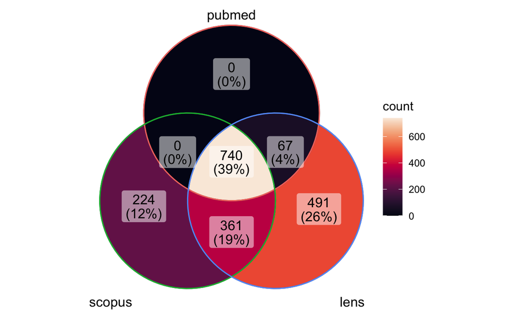

```r
ggVennDiagram::ggVennDiagram(
    x = cb_list[names(cb_list) != "myncbi"],
    edge_size = 0.5
) +
    viridis::scale_fill_viridis(option = "F")
```

Overlap of all lists (*includes MyNCBI results*):

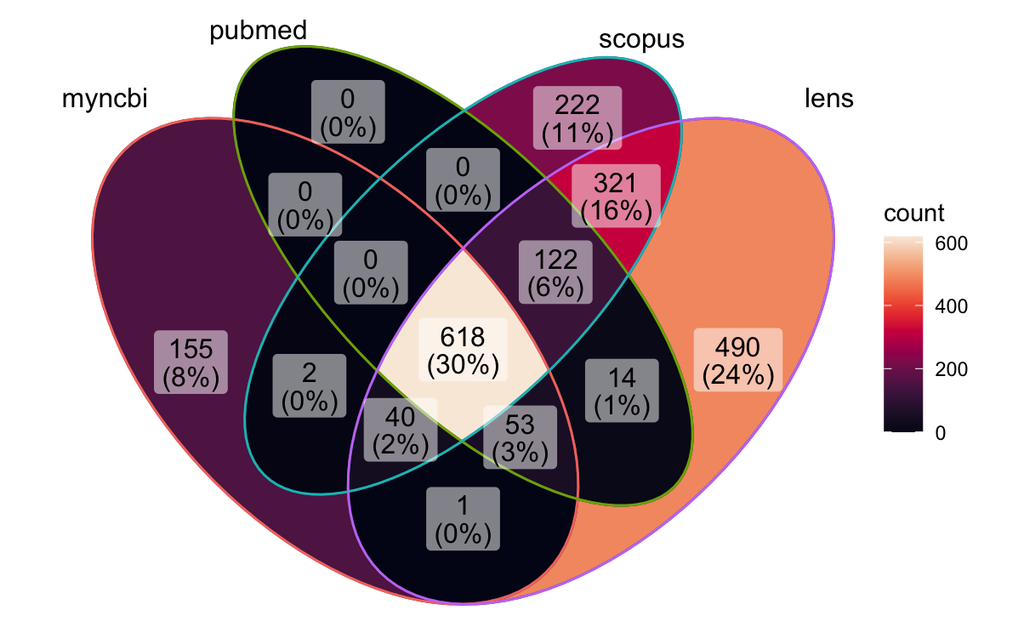

```r
ggVennDiagram::ggVennDiagram(
    x = cb_list,
    edge_size = 0.5
) +
    viridis::scale_fill_viridis(option = "F")
```

## Lens.org-Only Citations

| publication_type | n | pct |
| --- | --- | --- |
| preprint | 159 | 32.4% |
| journal article | 105 | 21.4% |
| conference proceedings article | 66 | 13.5% |
| unknown | 65 | 13.3% |
| book | 36 | 7.3% |
| book chapter | 32 | 6.5% |
| dissertation | 14 | 2.9% |
| conference proceedings | 12 | 2.4% |
| other | 1 | 0.2% |

Or as a pie chart:

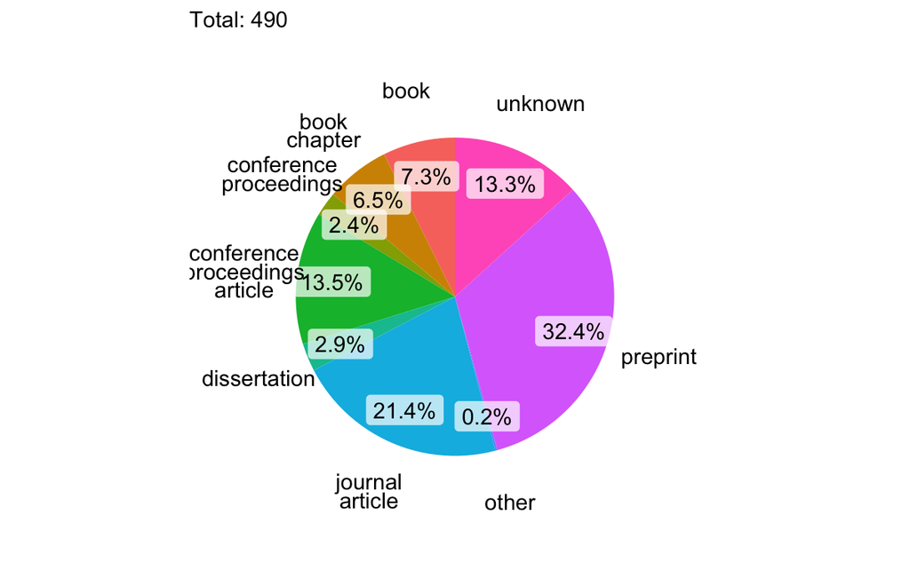

```r
dplyr::count(lens_only, publication_type) %>%
    dplyr::mutate(
        pct = paste0(round(n / sum(n) * 100, 1), "%"),
        publication_type = dplyr::if_else(
            is.na(publication_type),"unknown",
            stringr::str_replace_all(publication_type, " ", "\n")
        )
    ) %>%
    gg_pie()
```

Those **UNKNOWN** scholarly works are:

| index | lens_id | title | date_published | publication_year | publication_type | source_title | issns | publisher | source_country | authors | abstract | volume | issue_number | start_page | end_page | fields_of_study | keywords | mesh_terms | chemicals | funding | source_urls | external_url | pmid | doi | microsoft_academic_id | pmcid | citing_patents_count | references | citing_works_count | … |
| --- | --- | --- | --- | --- | --- | --- | --- | --- | --- | --- | --- | --- | --- | --- | --- | --- | --- | --- | --- | --- | --- | --- | --- | --- | --- | --- | --- | --- | --- | --- |
| 1562 | 004-963-159-279-304 | Building a Web of Linked Data Resources to Advance Neuroscience Research Authors |  | 2016 | NA | NA | NA | NA | NA | H. Wheeler | NA | NA | NA | NA | NA | World Wide Web; Neuroscience Information Framework; Neuroinformatics; Data science; Neuroscience research; Computer science; Linked data | NA | NA | NA | NA | NA | NA | NA | NA | 2462437927 | NA | 0 | 003-667-258-869-032; 003-836-416-607-594; 007-939-775-319-655; 008-441-929-868-39X; 008-914-701-728-582; 010-640-521-933-18X; 011-948-426-219-620; 014-511-970-159-745; 015-069-870-503-294; 017-217-687… | 0 | … |
| 1590 | 010-891-678-613-05X | Effective Feature Representation for Clinical Text Concept Extraction | 2018-10-31 | 2018 | NA | arXiv: Computation and Language | NA | NA | NA | Yifeng Tao; Bruno Godefroy; Guillaume Genthial; Christopher Potts | Crucial information about the practice of healthcare is recorded only in free-form text, which creates an enormous opportunity for high-impact NLP. However, annotated healthcare datasets tend to be sm… | NA | NA | NA | NA | Artificial intelligence; Ontology (information science); Natural language processing; Representation (systemics); Concept extraction; Computer science; Word (computer architecture); Feature (computer … | NA | NA | NA | NA | https://arxiv.org/abs/1811.00070 https://arxiv.org/pdf/1811.00070 https://ui.adsabs.harvard.edu/abs/2018arXiv181100070T/abstract | https://arxiv.org/abs/1811.00070 | NA | NA | 2898855968 | NA | 0 | 001-457-565-733-794; 001-741-313-866-062; 007-814-872-111-101; 010-436-208-086-596; 012-033-258-399-378; 018-349-904-385-333; 018-409-528-222-208; 019-729-680-880-124; 021-231-910-581-992; 026-250-643… | 1 | … |
| 1592 | 011-067-067-179-822 | SMR: Medical Knowledge Graph Embedding for Safe Medicine Recommendation | 2017-10-16 | 2017 | NA | arXiv: Information Retrieval | NA | NA | NA | Fang Gong; Meng Wang; Haofen Wang; Sen Wang; Mengyue Liu | Most of the existing medicine recommendation systems that are mainly based on electronic medical records (EMRs) are significantly assisting doctors to make better clinical decisions benefiting both pa… | NA | NA | NA | NA | DrugBank; Medical record; Information retrieval; Ontology; Medical knowledge; Computer science; Medical diagnosis; Recommender system; Graph embedding; Big data | NA | NA | NA | NA | https://arxiv.org/abs/1710.05980 https://arxiv.org/pdf/1710.05980v3 http://ui.adsabs.harvard.edu/abs/2017arXiv171005980G/abstract https://128.84.21.199/abs/1710.05980 | https://arxiv.org/abs/1710.05980 | NA | NA | 3107013868 | NA | 0 | 004-412-715-083-302; 007-754-560-869-958; 023-057-865-380-519; 032-430-038-087-692; 034-251-915-312-847; 039-357-509-215-803; 040-933-265-866-471; 062-286-952-517-29X; 062-449-192-706-779; 062-612-999… | 0 | … |
| 1625 | 021-741-095-782-789 | Utilising Graph Machine Learning within Drug Discovery and Development | 2020-12-09 | 2020 | NA | arXiv: Quantitative Methods | NA | NA | NA | Thomas Gaudelet; Ben Day; Arian R. Jamasb; Jyothish Soman; Cristian Regep; Gertrude Liu; Jeremy B. R. Hayter; Richard Vickers; Charles Roberts; Jian Tang; David Roblin; Tom L. Blundell; Michael M. Bro… | Graph Machine Learning (GML) is receiving growing interest within the pharmaceutical and biotechnology industries for its ability to model biomolecular structures, the functional relationships between… | NA | NA | NA | NA | Drug repositioning; Machine learning; Graph (abstract data type); Data type; Artificial intelligence; Key terms; Computer science; Drug development; Drug discovery | NA | NA | NA | NA | http://ui.adsabs.harvard.edu/abs/2020arXiv201205716G/abstract http://export.arxiv.org/pdf/2012.05716 https://arxiv.org/abs/2012.05716 https://arxiv.org/pdf/2012.05716.pdf | http://ui.adsabs.harvard.edu/abs/2020arXiv201205716G/abstract | NA | NA | 3111099750 | NA | 0 | 000-149-254-047-497; 000-290-621-900-801; 001-832-531-634-802; 001-997-757-669-130; 002-352-027-220-786; 003-460-660-930-681; 003-539-836-008-765; 003-735-457-147-034; 004-291-550-243-903; 005-088-921… | 5 | … |
| 1635 | 023-448-260-058-373 | Mass spectrometry in clinical protein biomarker discovery | 2014-02-14 | 2014 | NA | NA | NA | NA | NA | Ville Parviainen | NA | NA | NA | NA | NA | Biomarker discovery; Mass spectrometry; Chemistry; Computational biology | NA | NA | NA | NA | https://helda.helsinki.fi/bitstream/handle/10138/42746/parviainen_dissertation.pdf;sequence=1 https://helda.helsinki.fi/handle/10138/42746 https://helda.helsinki.fi/bitstream/10138/42746/1/parviainen_… | https://helda.helsinki.fi/handle/10138/42746 | NA | NA | 1168079072 | NA | 0 | 000-101-495-160-519; 000-906-494-798-631; 001-550-132-948-884; 002-055-781-505-352; 002-389-733-176-865; 002-709-192-412-983; 002-875-246-112-868; 002-880-498-827-946; 003-846-763-825-771; 003-882-765… | 0 | … |
| 1642 | 025-065-681-330-616 | A Quest for Missing Proteins: update 2015 on Chromosome-Centric Human |  | 2015 | NA | NA | NA | NA | NA | Peter Horvatovich; Emma Lundberg; Yu-Ju Chen; Edouard C. Nice; Robert J. A. Goode; Simon Yu; Shoba Ranganathan; Mark S. Baker; Gilberto B. Domont; Erika Velasquez; Siqi Liu; Quanhui Wang; Yuanfang Gua… | NA | NA | NA | NA | NA | Chromosome (genetic algorithm); Computational biology; Biology | NA | NA | NA | NA | NA | NA | NA | NA | 2611219074 | NA | 0 | 000-029-077-547-354; 000-056-613-927-806; 000-406-442-467-194; 000-583-188-105-370; 001-257-314-103-505; 001-983-357-921-475; 002-015-261-929-841; 002-494-359-153-771; 003-348-973-542-831; 003-499-269… | 0 | … |
| 1647 | 026-385-735-376-169 | Augmenting the Medical Subject Headings vocabulary with semantically rich variants to improve disease mention normalisation |  | 2015 | NA | NA | NA | NA | NA | Riza Theresa Batista-Navarro; Sophia Ananiadou | NA | NA | NA | 311 | 316 | Artificial intelligence; Natural language processing; Information retrieval; Vocabulary; Subject (documents); Disease; Computer science | NA | NA | NA | NA | https://www.research.manchester.ac.uk/portal/en/publications/augmenting-the-medical-subject-headings-vocabulary-with-semantically-rich-variants-to-improve-disease-mention-normalisation(cb6633d1-0c2c-4… | https://www.research.manchester.ac.uk/portal/en/publications/augmenting-the-medical-subject-headings-vocabulary-with-semantically-rich-variants-to-improve-disease-mention-normalisation(cb6633d1-0c2c-4… | NA | NA | 2594667521 | NA | 0 | 004-483-887-708-610; 006-104-664-386-845; 008-815-516-839-64X; 021-444-432-074-257; 046-006-683-697-624; 053-202-420-529-778; 053-569-478-519-231; 055-207-491-046-373; 058-526-240-853-16X; 074-526-791… | 2 | … |
| 1655 | 028-772-784-003-716 | Known allosteric proteins have central roles in genetic disease | 2021-07-09 | 2021 | NA | arXiv: Molecular Networks | NA | NA | NA | Gyorgy Abrusan; David B. Ascher; Michael Inouye | Allostery is a form of protein regulation, where ligands that bind sites located apart from the active site can modify the activity of the protein. The molecular mechanisms of allostery have been exte… | NA | NA | NA | NA | Cancer; Allosteric regulation; Genetic association; Disease; Protein regulation; Active site; Central nervous system; Genetics; Biology | NA | NA | NA | NA | https://arxiv.org/abs/2107.04318v1 https://arxiv.org/pdf/2107.04318 https://ui.adsabs.harvard.edu/abs/2021arXiv210704318A/abstract | https://arxiv.org/abs/2107.04318v1 | NA | NA | 3182705924 | NA | 0 | 000-037-455-561-71X; 003-016-347-900-629; 004-901-677-927-873; 005-428-020-924-657; 005-624-666-726-682; 006-094-332-405-556; 007-725-282-600-760; 008-700-789-219-235; 011-407-588-759-484; 011-959-809… | 0 | … |
| 1673 | 033-908-915-584-09X | Utilizing Knowledge Bases In Information Retrieval For Clinical Decision Support And Precision Medicine | 2019-08-07 | 2019 | NA | NA | NA | NA | NA | Saeid Balaneshin-kordan | Accurately answering queries that describe a clinical case and aim at finding articles in a collection of medical literature requires utilizing knowledge bases in capturing many explicit and latent as… | NA | NA | NA | NA | Statistical model; Precision medicine; Structure (mathematical logic); Information retrieval; Query analysis; Clinical case; Genetic variants; Computer science; Representation (mathematics); Clinical … | NA | NA | NA | NA | https://digitalcommons.wayne.edu/cgi/viewcontent.cgi?article=3142&context=oa_dissertations https://digitalcommons.wayne.edu/oa_dissertations/2143/ | https://digitalcommons.wayne.edu/oa_dissertations/2143/ | NA | NA | 2969031543 | NA | 0 | 003-548-398-186-442; 003-874-797-596-928; 004-497-468-781-052; 005-396-056-001-324; 005-919-050-451-99X; 006-938-481-070-46X; 006-967-407-038-165; 007-598-757-355-350; 008-113-690-416-54X; 008-559-028… | 0 | … |
| 1681 | 036-741-733-181-713 | Fast and scalable learning of neuro-symbolic representations of biomedical knowledge | 2018-04-30 | 2018 | NA | arXiv: Artificial Intelligence | NA | NA | NA | Asan Agibetov; Matthias Samwald | In this work we address the problem of fast and scalable learning of neuro-symbolic representations for general biological knowledge. Based on a recently published comprehensive biological knowledge g… | NA | NA | NA | NA | Machine learning; Artificial intelligence; Simple (abstract algebra); Link (geometry); Knowledge graph; Biomedical knowledge; Computer science; Embedding; Scalability; Feature learning | NA | NA | NA | NA | https://arxiv.org/pdf/1804.11105 https://arxiv.org/abs/1804.11105 | https://arxiv.org/abs/1804.11105 | NA | NA | 2798371940 | NA | 0 | 005-678-427-484-78X; 011-792-182-938-734; 018-465-971-705-77X; 032-430-038-087-692; 051-964-420-235-188; 056-894-722-066-827; 060-076-646-571-695; 061-039-512-735-504; 080-032-275-012-464; 100-840-528… | 1 | … |

[output cut: 55 more lines]

## Scopus-Only citations

| publication_type | n | pct |
| --- | --- | --- |
| Conference Proceeding \| Conference Paper | 135 | 60.8% |
| Journal \| Article | 61 | 27.5% |
| Book \| Book Chapter | 11 | 5% |
| Journal \| Review | 6 | 2.7% |
| Book Series \| Conference Paper | 3 | 1.4% |
| Journal \| Conference Paper | 3 | 1.4% |
| Book \| Book | 1 | 0.5% |
| Book Series \| Article | 1 | 0.5% |
| Book Series \| Review | 1 | 0.5% |

Or as a pie chart:

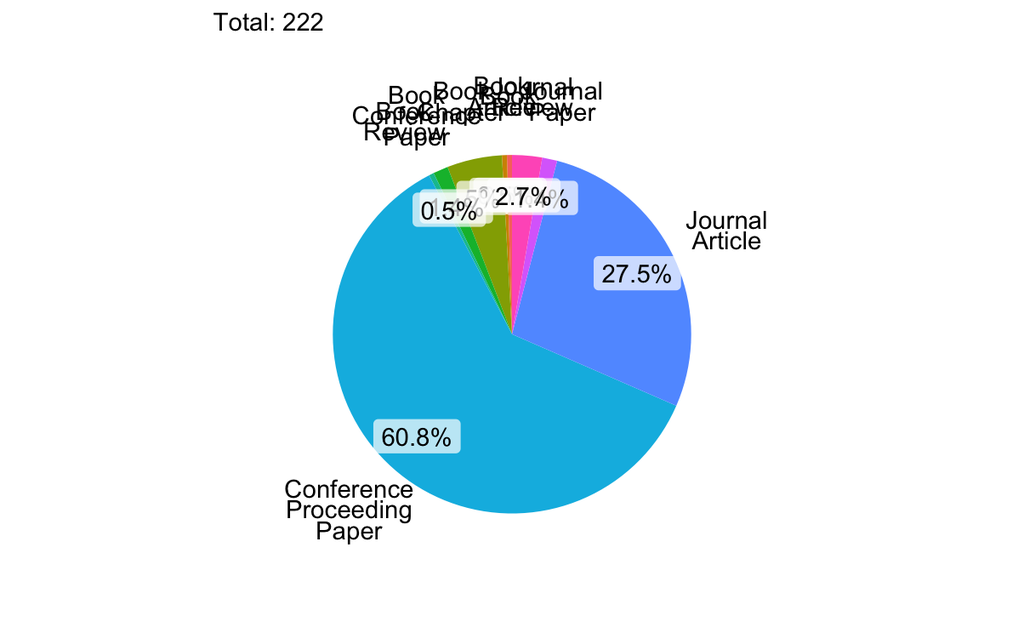

```r
scopus_only %>%
    dplyr::mutate(
        publication_type = stringr::str_replace_all(
            pub_type,
            c("Series\\|" = "", "\\|Book" = "", "\\|Conference" = "",
              "\\|" = " ")
        )
    ) %>%
    dplyr::count(publication_type) %>%
    dplyr::mutate(
        pct = paste0(round(n / sum(n) * 100, 1), "%"),
        publication_type = dplyr::if_else(
            is.na(publication_type),"unknown",
            stringr::str_replace_all(publication_type, " ", "\n")
        )
    ) %>%
    gg_pie()
```

# Discussion

# Conclusion

If Lens.org had been this good when I first started it might have been better to use it alone, but now that I’ve done the hard work of combining PubMed & Scopus results it doesn’t seem worth combining the info from Lens.org at this time.

Lens.org’s online tools might be useful on their own for code-free exploration.

# Additional Code

```r
lens_cb_long <- lens_cb %>%
    dplyr::select(lens_id, doi, pmid, pmcid) %>%
    split_col("doi") %>%
    split_col("pmid") %>%
    split_col("pmcid") %>%
    tidyr::pivot_longer(
        cols = tidyselect::matches("doi|pmid|pmcid"),
        names_to = c(".value", "n"),
        names_sep = "_",
        names_transform = list(n = as.integer),
        values_to = "id"
    ) %>%
    dplyr::filter(!(n > 1 & dplyr::if_all(c(doi, pmid, pmcid), is.na))) %>%
    dplyr::arrange(lens_id, n) %>%
    dplyr::mutate(index = dplyr::row_number()) %>%
    dplyr::select(index, n, dplyr::contains("id"), doi, dplyr::everything())

lens_cb_long <- DO.utils::match_citations(lens_cb_long, cb, add_col = TRUE)
```